# Check Ghost Detectors

Adam Lyon

2017-03-07

# 1 Executive Summary

James introduced “Ghost Detectors” that live in the Geant Parallel World so that we can add sensitive volumes without overlapping with existing structures. A cylindrical volume just inside the vacuum chamber is being used to detect muons that escape the ring (not stored). The purpose of this document is to see if the Ghost detectors are doing resonable things. There’s anecdotal evidence of seeing multiple hits from the primary muon in the Ghost loss cylinder – that needs to be checked. I ran 100 events to check.

## 1.2 Technical notes

- For `rgl`,
  - Do not use `rgl.clear`. Use `clear3d()` insted.
  - If you get a grey background, issue `open3d()` to return to normalcy
  - Use `view3d` to set the initial view. `view3d(phi=90, theta=-90)` is our traditional top down view. Still haven’t figured out how to read the current view from webgl

# 2 Introduction

Renee created a Ghost cylinder detector that surrounds the vacuum chamber outer wall to find particles that are lost. The goal here is to have confidence that these hits make sense, especially if a particle makes more than one hit in the ghost detector. I have also added a ghost “near world” detector that is a cylinder just inside the world cube. Those hits should also make sense. I have turned on detailed stepping data to look at if we find a strange event.

I have a file at `/home/me/gm2/renee_arr/try/ARR_unified_everything_cyl_100_withStepInfo.root` with 100 events.

# 3 Obtain the data

Use PyRoot to access the data.

```r
# Load useful libraries
library(reticulate)
library(stringr)
library(dplyr)
library(ggplot2)
```

Set up the python side

```r
py_config()
```

```
python:         /cvmfs/gm2.opensciencegrid.org/prod7/external/python/v2_7_11/Linux64bit+3.10-2.17/bin/python
libpython:      /cvmfs/gm2.opensciencegrid.org/prod7/external/python/v2_7_11/Linux64bit+3.10-2.17/lib/libpython2.7.so
pythonhome:     /cvmfs/gm2.opensciencegrid.org/prod7/external/python/v2_7_11/Linux64bit+3.10-2.17:/cvmfs/gm2.opensciencegrid.org/prod7/external/python/v2_7_11/Linux64bit+3.10-2.17
version:        2.7.11 (default, May  2 2016, 15:20:38)  [GCC 4.8.5 20150623 (Red Hat 4.8.5-4)]
numpy:          /home/me/.local/lib/python2.7/site-packages/numpy
numpy_version:  1.12.0

python versions found:
 /cvmfs/gm2.opensciencegrid.org/prod7/external/python/v2_7_11/Linux64bit+3.10-2.17/bin/python
 /usr/bin/python
```

```r
# main is our connection to the python session
main <- py_run_string('
import ROOT
import numpy
import random
import time
')
```

We have `numpy`, but we won’t use it.

Prepare PyRoot to read gallery data

```r
# Helper function to read a header into PyROOT
read_header <- function(h) {
  str_interp("ROOT.gROOT.ProcessLine('#include \"${h}\"')", list(h=h)) %>%
    py_run_string()
}
# Load in gallery information
read_header("gallery/ValidHandle.h")
# Load in dictionary and prepare to get a handle
provide_get_valid_handle <- function(klass) {
  paste0("ROOT.gROOT.ProcessLine(",
         "'template gallery::ValidHandle<",klass,"> ",
         "gallery::Event::getValidHandle<",klass,">(art::InputTag const&) const;')") %>%
    py_run_string()
}
```

We want to look at `GhostDetectorArtRecord` (see http://tinyurl.com/gkrd6aj). Note that the input tag for the ring ghost is `artg4:GhostCylinderDetector` and for the “near world” ghost it is `artg4:GhostNearWorldDetector`.

```r
# Prepare for GhostDetectorArtRecord
provide_get_valid_handle('std::vector<gm2truth::GhostDetectorArtRecord>')
```

Prepare the input tags

```r
py_run_string("
cylIT = ROOT.art.InputTag('artg4:GhostCylinderDetector')
nwIT  = ROOT.art.InputTag('artg4:GhostNearWorldDetector')
")
```

Make the file list for our only file

```r
artFile = "/home/me/gm2/renee_arr/try/mdc2/ARR_unified_everything_cyl.root"
main$artFile = artFile
py_run_string("
files = ROOT.vector(ROOT.string)(1, artFile)
")
```

Define a helper function to fill the data

```r
py_run_string('
def fill(ev, w, g, cols, rnge):
  row = [w, ev.eventEntry(), ev.fileEntry(), g.particleID, g.trackID, g.parentTrackID,
            g.position.x(), g.position.y(), g.position.z(),
            g.momentum.x(), g.momentum.y(), g.momentum.z()]
  [ cols[i].append(row[i]) for i in rnge ]   # side-effect here!
')
```

Load the Ghost detector data

```r
py_run_string('
ev = ROOT.gallery.Event(files)  # Open the file
get_gh = ev.getValidHandle(ROOT.vector(ROOT.gm2truth.GhostDetectorArtRecord)) # Prepare the getter
# Prepare the columns
colNames = ["which", "eventEntry", "fileEntry", "particleID", "trackID", "parentTrackID",
            "x", "y", "z", "px", "py", "pz"]  # This ordering is important
forRange = xrange(len(colNames))
allVals = [ [] for i in forRange ]
# Keep track of timing
startTotalTime = time.clock()
times = []
# Loop over events with gallery
while not ev.atEnd():
  startTime = time.clock()

  # Get handles to the data
  gd_cyl_h = get_gh(cylIT)
  # Fill the cylinder Ghost hit data
  if not gd_cyl_h.empty():
    gd_cyl = gd_cyl_h.product()
    for g in gd_cyl:
      fill(ev, 0, g, allVals, forRange)
  # Do the same for the near world hits
  gd_nw_h  = get_gh(nwIT)
  if not gd_nw_h.empty():
    gd_nw = gd_nw_h.product()
    for g in gd_nw:
      fill(ev, 1, g, allVals, forRange)

  times.append(time.clock() - startTime)
  ev.next()
print "Total Processing time is %s s" % (time.clock() - startTotalTime)
print "Created %s rows" % (len(allVals[0]))
')
```

[output not shown]

```r
l <- main$allVals ; names(l) <- main$colNames ; df <- tbl_df(l)
```

[output not shown]

We need to clean up the data a little:

- Turn `particleID` into a name (see http://pdg.lbl.gov/2007/reviews/montecarlorpp.pdf)
- Turn `which` into a name

```r
# The PDG values we need to care about
df %>% distinct(particleID) %>% arrange(particleID) -> pdgVals
pdgVals
```

| particleID |
| --- |
| -14 |
| -13 |
| -11 |
| 11 |
| 12 |
| 22 |
| 2112 |

```r
# The corresponding PDG names
pdgNames <- c("anti-nu-mu", "mu+", "e+", "e-", "nu-e", "gam", "n")
```

```r
# Do the conversions and drop the old columns
df %>% mutate(pdg = factor(particleID, levels=pdgVals$particleID, labels=pdgNames),
                w = factor(which, levels=c(0,1), labels=c("cyl", "nw"))) -> df
df
```

| which | eventEntry | fileEntry | particleID | trackID | parentTrackID | x | y | z | px | py | pz | pdg | w |
| --- | --- | --- | --- | --- | --- | --- | --- | --- | --- | --- | --- | --- | --- |
| 0 | 0 | 0 | 22 | 159 | 85 | 7259.7101 | 99.000000 | -3168.13078 | -1.192770e-01 | 1.135531e+00 | 1.750276e+00 | gam | cyl |
| 0 | 0 | 0 | 22 | 150 | 102 | 7353.7566 | 99.000000 | -2961.08959 | 1.569648e-01 | 1.606239e-01 | 8.864299e-02 | gam | cyl |
| 0 | 0 | 0 | 22 | 146 | 108 | 7380.5596 | 99.000000 | -2910.04820 | 7.629124e-02 | 2.227313e-01 | 7.044693e-02 | gam | cyl |
| 0 | 0 | 0 | 12 | 129 | 1 | 7579.4153 | 99.000000 | -2734.44532 | 6.388668e+00 | 9.415109e+00 | -4.766617e+01 | nu-e | cyl |
| 0 | 0 | 0 | -14 | 128 | 1 | 6740.6722 | -99.000000 | 367.18189 | -1.265101e+01 | -2.441388e+00 | 4.512535e+01 | anti-nu-mu | cyl |
| 0 | 0 | 0 | 22 | 642 | 551 | 7206.7559 | 99.000000 | -3125.49577 | -1.776788e+00 | 2.105106e-01 | 2.443320e+00 | gam | cyl |
| 0 | 0 | 0 | 22 | 642 | 551 | 7151.2369 | 100.000000 | -3043.25855 | 1.884185e-01 | -2.633483e-01 | -4.534086e-03 | gam | cyl |
| 0 | 0 | 0 | 22 | 640 | 551 | 7259.9088 | 99.000000 | -3146.39262 | 3.548941e-02 | 7.582143e-01 | 1.147775e+00 | gam | cyl |
| 1 | 0 | 0 | 12 | 129 | 1 | 8013.5480 | 738.790115 | -5973.53108 | 6.388668e+00 | 9.415109e+00 | -4.766617e+01 | nu-e | nw |
| 1 | 0 | 0 | -14 | 128 | 1 | 4316.2357 | -566.867095 | 9014.99499 | -1.265101e+01 | -2.441388e+00 | 4.512535e+01 | anti-nu-mu | nw |

[output cut: 775 more lines]

# 4 Analyze primary muon hits in cylinder ghost detector

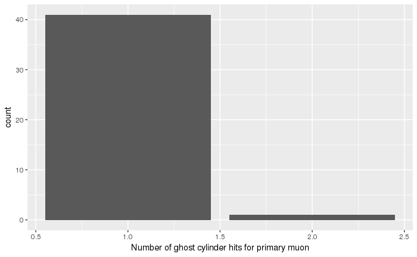

```r
df %>% filter(w == 'cyl', pdg == 'mu+', trackID == 1, parentTrackID == 0) -> mus
mus %>% group_by(eventEntry) %>% summarise(n = n()) -> cylHitsPerEvent
ggplot(cylHitsPerEvent, aes(n)) + geom_bar() + xlab('Number of ghost cylinder hits for primary muon')
```

How many mupn ghost cylinder hits to we see total?

```r
cylHitsPerEvent %>% summarise(total = sum(n))
```

[output not shown]

**NOTE: Renee says that my code has the wrong radius for the Ghost cylinder!! She made a correction that makes it a little bigger. I’ll try this code. She thinks that will make many of these double hits go away.**

Where are these hits?

```r
# Load a 3D graphics library
library(rgl)
tmp <- open3d()  # see http://tinyurl.com/hcxy9nh
```

Make a cylindrical representation of the ring

```r
ring <- cylinder3d( center=rbind(c(0,-90, 0), c(0,90,0)),
                    radius=7112,
                    sides=20, closed = F)
```

```r
clear3d()
plot3d(x=mus$x, y=mus$y, z=mus$z, type='p', main='Ghost Cylinder Hits',
       xlab="x", ylab="y", zlab="z", xlim=c(-9000, 9000), zlim=c(-9000, 9000))
plot3d(ring, add=T, alpha=0.2)
view3d(phi=90, theta=-90)
rglwidget()
```

[interactive chart not shown]

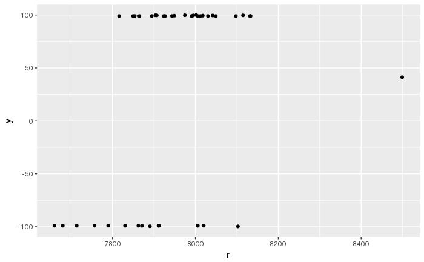

```r
mus %>% mutate(r = sqrt(x*x+z*z)) -> mus
ggplot(mus, aes(r,y)) +  geom_point()
```

And if we unroll the ring…

```r
mus %>% mutate(phirad = atan2(z,x))  %>% mutate(phideg = ifelse(phirad>=0, phirad, 2*pi+phirad)*180/pi) -> mus
```

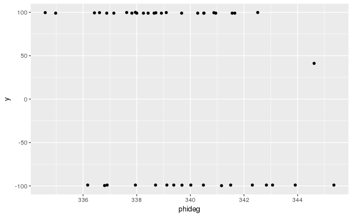

```r
ggplot(mus, aes(phideg, y)) + geom_point()
```

## 4.1 Mulitple cylindrical ghost hits

Let’s look at some events with more than one hit in the ghost detector for the muon.

```r
cylHitsPerEvent %>% filter(n==2)
```

| eventEntry | n |
| --- | --- |
| 69 | 2 |

```r
names(mus)
```

```
 [1] "which"         "eventEntry"    "fileEntry"     "particleID"    "trackID"
 [6] "parentTrackID" "x"             "y"             "z"             "px"
[11] "py"            "pz"            "pdg"           "w"             "r"
[16] "phirad"        "phideg"
```

```r
mus %>% filter(eventEntry == 69) %>%
        mutate(r = sqrt(x*x+z*z),
               p = sqrt(px*px+py*py+pz*pz)) %>%
        select(r, x, y, z, p)
```

| r | x | y | z | p |
| --- | --- | --- | --- | --- |
| 7926.764 | 7182.733 | 99.00000 | -3352.899 | 1272.5828 |
| 7903.554 | 7308.572 | 99.72375 | -3008.477 | 790.3755 |

There are some hints here!

Where are those hits?

```r
clear3d()
with(mus %>% filter(eventEntry==69), {
  plot3d(x=x, y=y, z=z, type='p', main='Ghost Cylinder Hits',
         xlab="x", ylab="y", zlab="z", xlim=c(-9000, 9000), zlim=c(-9000, 9000))
  plot3d(ring, add=T, alpha=0.2)
})
view3d(phi=90, theta=-90)
rglwidget()
```

[interactive chart not shown]

Let’s get the stepping data

```r
provide_get_valid_handle('std::vector<gm2ringsim::GeantTrackRecord>')
```

```r
py_run_string("gtIT = ROOT.art.InputTag('artg4:KeepStepsAction')")
```

We’re going to return both the `GeantTrackRecord` and the constituent `GeantStep` objects. Let’s organize things

```r
py_run_string('
class GeantTrackDF:
  def __init__(self):
    self.colNames = ["eventEntry", "fileEntry", "trackID", "parentID", "pdgValue", "status", "nSteps"]
    self.forRange = xrange(len(self.colNames))
    self.vals = [ [] for i in self.forRange ]
  def fill(self, ev, g):
    row = [ev.eventEntry(), ev.fileEntry(), g.trackID(), g.parentId(), g.pdg(), g.trackStatus(), g.steps().size() ]
    [ self.vals[i].append(row[i]) for i in self.forRange ]   # side-effect here!
class GeantStepDF:
  def __init__(self):
    self.colNames = ["eventEntry", "fileEntry", "trackID", "globalStepNum", "e", "dt", "l", "gt", "lt",
                     "x", "y", "z", "px", "py", "pz"]
    self.forRange = xrange(len(self.colNames))
    self.vals = [ [] for i in self.forRange ]
  def fill(self, trackID, ev, s):
    row = [ev.eventEntry(), ev.fileEntry(), trackID, s.globalStepNum(), s.totalEnergyDeposit(),
           s.deltaTime(), s.stepLength(), s.localTime(), s.globalTime(), s.pos()[0], s.pos()[1], s.pos()[2],
           s.p()[0], s.p()[1], s.p()[2] ]
    [ self.vals[i].append(row[i]) for i in self.forRange ]   # side-effect here!
')
```

```r
py_run_string('
ev = ROOT.gallery.Event(files)  # Open the file
get_gt = ev.getValidHandle(ROOT.vector(ROOT.gm2ringsim.GeantTrackRecord)) # Prepare the getter
# Prepare the columns
gtdf = GeantTrackDF()
gsdf = GeantStepDF()
# Keep track of timing
startTotalTime = time.clock()
times = []
# Loop over events with gallery
while not ev.atEnd():
  if ev.eventEntry() != 55: # Only event 55
    ev.next()
    continue
  startTime = time.clock()

  # Get handles to the data
  gt_h = get_gt(gtIT)
  # Fill the GeantTrackRecord
  if not gt_h.empty():
    gt = gt_h.product()
    for aTrack in gt:
      gtdf.fill(ev, aTrack)

      # Get the steps
      gs = aTrack.steps()
      for aStep in gs:
        gsdf.fill(aTrack.trackID(), ev, aStep)
  times.append(time.clock() - startTime)
  ev.next()
print "Total Processing time is %s s" % (time.clock() - startTotalTime)
')
```

```
Successfully opened file /home/me/gm2/renee_arr/try/ARR_unified_noInflector_cyl.root
Closing file, read 272300 bytes in 17 transactions
```

```r
gtl <- main$gtdf$vals ; names(gtl) <- main$gtdf$colNames ; gtdf <- tbl_df(gtl)
```

[output not shown]

```r
gsl <- main$gsdf$vals ; names(gsl) <- main$gsdf$colNames ; gsdf <- tbl_df(gsl)
```

```r
nrow(gtdf)
```

```
[1] 771
```

```r
nrow(gsdf)
```

```
[1] 3519
```

Just get the muon steps

```r
gsdf %>% filter(trackID==1) %>% arrange(globalStepNum)-> muSteps
muSteps
```

| eventEntry | fileEntry | trackID | globalStepNum | e | dt | l | gt | lt | x | y | z | px | py | pz |
| --- | --- | --- | --- | --- | --- | --- | --- | --- | --- | --- | --- | --- | --- | --- |
| 55 | 0 | 1 | 1 | 2.125369e-23 | 0.8698494772 | 260.62193788 | 0.0000000 | -5.89793650 | 6677.745 | -6.41141059 | -5025.99184 | 366.85282 | 9.5370535 | 3067.526461 |
| 55 | 0 | 1 | 2 | 2.125369e-23 | 0.8698494772 | 260.62193788 | 0.8698495 | -5.02808703 | 6708.693 | -5.60686421 | -4767.21513 | 366.85282 | 9.5370535 | 3067.526461 |
| 55 | 0 | 1 | 3 | 1.705290e-25 | 0.0069792370 | 2.09110004 | 0.8768287 | -5.02110779 | 6708.941 | -5.60041180 | -4765.13885 | 366.85282 | 9.5370535 | 3067.526461 |
| 55 | 0 | 1 | 4 | 2.446497e-23 | 1.0012773494 | 300.00000000 | 1.8781061 | -4.01983044 | 6744.578 | -4.67473201 | -4467.26442 | 367.60670 | 9.5130346 | 3067.436283 |
| 55 | 0 | 1 | 5 | 2.446497e-23 | 1.0012773494 | 300.00000000 | 2.8793834 | -3.01855309 | 6780.379 | -3.75333369 | -4169.40971 | 369.76418 | 9.4686741 | 3067.177095 |
| 55 | 0 | 1 | 6 | 2.446497e-23 | 1.0012773494 | 300.00000000 | 3.8806608 | -2.01727574 | 6816.395 | -2.83511424 | -3871.58095 | 372.03691 | 9.4463382 | 3066.902320 |
| 55 | 0 | 1 | 7 | 2.446497e-23 | 1.0012773494 | 300.00000000 | 4.8819381 | -1.01599839 | 6852.619 | -1.91790390 | -3573.77737 | 374.02495 | 9.4438749 | 3066.660510 |
| 55 | 0 | 1 | 8 | 2.446497e-23 | 1.0012773494 | 300.00000000 | 5.8832155 | -0.01472104 | 6888.981 | -1.00316422 | -3275.99048 | 374.04971 | 9.3813701 | 3066.657682 |
| 55 | 0 | 1 | 9 | 2.446497e-23 | 1.0012773494 | 300.00000000 | 6.8844928 | 0.98655631 | 6924.912 | -0.09728064 | -2978.15164 | 362.63311 | 9.2832572 | 3068.028940 |
| 55 | 0 | 1 | 10 | 2.446497e-23 | 1.0012773494 | 300.00000000 | 7.8857702 | 1.98783366 | 6958.361 | 0.79926917 | -2680.02591 | 319.87526 | 9.1209508 | 3072.781664 |

[output cut: 224 more lines]

Plot the Geant steps

```r
clear3d()
with(mus %>% filter(eventEntry==55), {
  plot3d(x=x, y=y, z=z, type='s', main='Ghost Cylinder Hits',
         xlab="x", ylab="y", zlab="z", xlim=c(-9000, 9000), zlim=c(-9000, 9000))
  plot3d(ring, add=T, alpha=0.2)
})
with(muSteps,{
  plot3d(x=x, y=y, z=z, col="red", add=T, type='p')
})
view3d(theta=45, phi=45)
rglwidget()
```

[interactive chart not shown]

Another view - our normal top down view

```r
view3d(phi=90, theta=-90)
rglwidget()
```

[interactive chart not shown]

THe muon enters where it should … good. But that’s quite a trip that the muon took!

Look at a table we did above…

```r
mus %>% filter(eventEntry == 55) %>%
        mutate(r = sqrt(x*x+z*z),
               p = sqrt(px*px+py*py+pz*pz)) %>%
        select(r, x, y, z, p)
```

| r | x | y | z | p |
| --- | --- | --- | --- | --- |
| 8230.000 | 6708.693 | -5.606864 | -4767.215 | 3089.400 |
| 7685.361 | 3656.287 | 99.824228 | 6759.906 | 1612.852 |
| 7885.857 | 3220.045 | 99.291227 | 7198.476 | 845.965 |
| 8028.993 | 2877.735 | 99.000000 | 7495.557 | 340.549 |

This is from the ghost cylinder hits. The momentum drops dramatically for each of the ‘u-turns’. Looks like scattering!

Let’s look at energy loss vs step number…

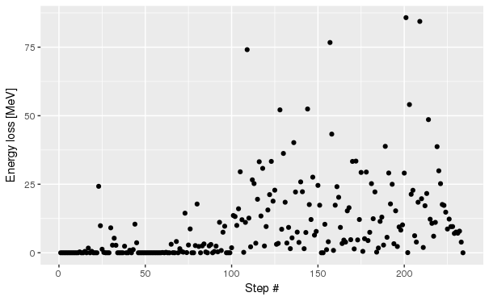

```r
muSteps %>% ggplot(aes(globalStepNum, e)) + geom_point() + xlab('Step #') + ylab('Energy loss [MeV]')
```

And now vs. radius

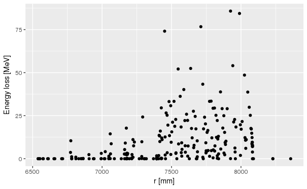

```r
muSteps %>% mutate(r = sqrt(x*x+z*z)) %>%
  ggplot(aes(r, e)) + geom_point() + xlab('r [mm]') + ylab('Energy loss [MeV]')
```

Looks like the muon hit somthing in the ring and kinked upward where it soon entered the magnet yoke. There is scattered extensively. Would be fun to see this ParaView.

### 4.1.2 Muon showering in event 55

Perhaps we can see the showering. Let’s just plot all of the steps. Fun! We need to split up the lines by trackID.

Let’s get the primary daughters of the muon

```r
gtdf %>% filter(parentID == 1 | trackID == 1) -> gtMuAndDaughters
head(gtMuAndDaughters$trackID)
```

```
[1] 139 140 141   2   3   4
```

Plot the steps as lines for the muon and its direct daughters (see [here](http://www.milanor.net/blog/dplyr-do-tips-for-using-and-programming/) for help with `do`),

```r
clear3d()
plot3d( x=0, y=0, z=0,  xlim=c(-10000, 10000), ylim=c(-210, 220), zlim=c(-10000, 10000),
        xlab='x', ylab='y', zlab='z')
gsdf %>%                                                       # gsdf has Geant step information for every track in the event
  filter(trackID %in% gtMuAndDaughters$trackID) %>%            # Only pick steps from the muon and its direct daughters
  arrange(trackID, globalStepNum) %>%                          # Order by track ID and then by step number
  select(trackID, x, y, z) %>%                                 # Only keep the columns we care about
  filter( y > -200, y < 200) %>%                               # Restrict the height
  group_by(trackID) %>%                                        # Split by track
  do(out = lines3d(x=.$x, y=.$y, z=.$z, col=.$trackID)) %>%    # Draw the lines for each track (note the use of "out=")
  invisible()  # Discard the output
view3d()
rglwidget()
```

[interactive chart not shown]

The muon is black and the other particles have a different color. If you zoom in really far, you can see some fuzz around the muon as it interacts and loses energy. Not nearly as interesting as an EM shower.